# Practical machine Learning Course Project

Nicolas Borchers Arriagada

26 March 2021

## Predicting “classe” of exercise with data from wearable devices

This is an R Markdown document showing the process of putting together a classification model, particularly a random forest model, to predict the exercise “classe” using different exercise characteristics as predictors.

# Load training and testing data

Read data from urls and load to train and test data frames. Check dimensions to see how many rows and columns

```r
train <- read.csv('https://d396qusza40orc.cloudfront.net/predmachlearn/pml-training.csv')
test <- read.csv('https://d396qusza40orc.cloudfront.net/predmachlearn/pml-testing.csv')

dim(train)
```

```
## [1] 19622   160
```

```r
dim(test)
```

```
## [1]  20 160
```

# Data cleaning

First, check for NA values within train data set, and calculate % of NA values for each column, as there are 160 columns, we’ll visualise a histogram. 67 out of 160 columns have more than 80% of NA values.

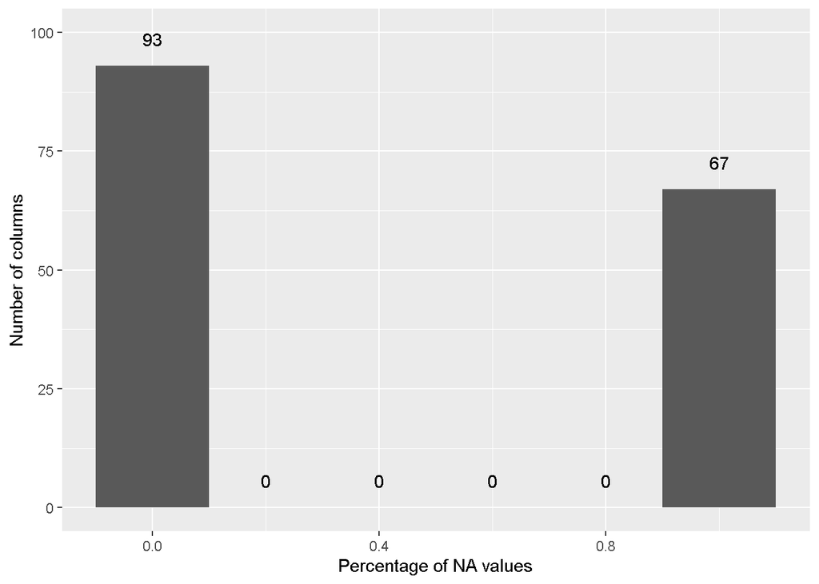

```r
na_perc <- lapply(train, function(x) sum(length(which(is.na(x))))/sum(length(x)))

df_na_perc <- na_perc %>%
  as.data.frame() %>%
  gather(Col_name, perc) %>%
  arrange(-perc)

ggplot(df_na_perc,aes(x=perc)) +
    stat_bin(binwidth=0.2) +
    ylim(0,100) +
    stat_bin(binwidth=0.2, geom="text", aes(label=..count..), vjust=-1.5) +
  xlab('Percentage of NA values') + ylab('Number of columns')
```

Remove all columns with more than 80% NA values in train set (all 67 cols with NAs removed, 93 cols left)

```r
train_no_nas <- train[,colSums(is.na(train)) < 0.8*nrow(train)]

dim(train_no_nas)
```

```
## [1] 19622    93
```

```r
str(train_no_nas)
```

```
## 'data.frame':    19622 obs. of  93 variables:
##  $ X                      : int  1 2 3 4 5 6 7 8 9 10 ...
##  $ user_name              : chr  "carlitos" "carlitos" "carlitos" "carlitos" ...
##  $ raw_timestamp_part_1   : int  1323084231 1323084231 1323084231 1323084232 1323084232 1323084232 1323084232 1323084232 1323084232 1323084232 ...
##  $ raw_timestamp_part_2   : int  788290 808298 820366 120339 196328 304277 368296 440390 484323 484434 ...
##  $ cvtd_timestamp         : chr  "05/12/2011 11:23" "05/12/2011 11:23" "05/12/2011 11:23" "05/12/2011 11:23" ...
##  $ new_window             : chr  "no" "no" "no" "no" ...
##  $ num_window             : int  11 11 11 12 12 12 12 12 12 12 ...
##  $ roll_belt              : num  1.41 1.41 1.42 1.48 1.48 1.45 1.42 1.42 1.43 1.45 ...
##  $ pitch_belt             : num  8.07 8.07 8.07 8.05 8.07 8.06 8.09 8.13 8.16 8.17 ...
##  $ yaw_belt               : num  -94.4 -94.4 -94.4 -94.4 -94.4 -94.4 -94.4 -94.4 -94.4 -94.4 ...
##  $ total_accel_belt       : int  3 3 3 3 3 3 3 3 3 3 ...
##  $ kurtosis_roll_belt     : chr  "" "" "" "" ...
##  $ kurtosis_picth_belt    : chr  "" "" "" "" ...
##  $ kurtosis_yaw_belt      : chr  "" "" "" "" ...
```

[output cut: 79 more lines]

Check for columns with blank values, 33 additional columns are identified.

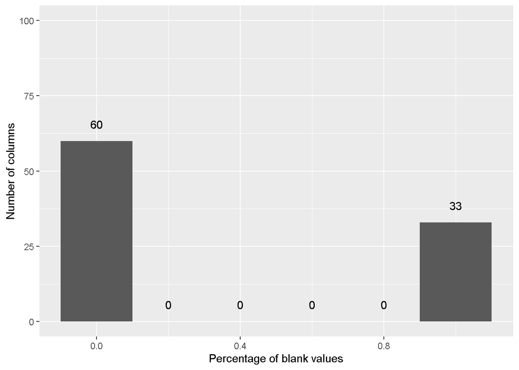

```r
blank_perc <- lapply(train_no_nas, function(x) sum(length(which(x == '')))/sum(length(x)))

df_blank_perc <- blank_perc %>%
  as.data.frame() %>%
  gather(Col_name, perc) %>%
  arrange(-perc)

ggplot(df_blank_perc,aes(x=perc)) +
    stat_bin(binwidth=0.2) +
    ylim(0,100) +
    stat_bin(binwidth=0.2, geom="text", aes(label=..count..), vjust=-1.5) +
  xlab('Percentage of blank values') + ylab('Number of columns')
```

Remove all columns with more than 80% blank values in train set (33 cols removed)

```r
train_no_nas_no_blanks <- train_no_nas[,colSums(train_no_nas == '') < 0.8*nrow(train_no_nas)]

dim(train_no_nas_no_blanks)
```

```
## [1] 19622    60
```

```r
str(train_no_nas_no_blanks)
```

```
## 'data.frame':    19622 obs. of  60 variables:
##  $ X                   : int  1 2 3 4 5 6 7 8 9 10 ...
##  $ user_name           : chr  "carlitos" "carlitos" "carlitos" "carlitos" ...
##  $ raw_timestamp_part_1: int  1323084231 1323084231 1323084231 1323084232 1323084232 1323084232 1323084232 1323084232 1323084232 1323084232 ...
##  $ raw_timestamp_part_2: int  788290 808298 820366 120339 196328 304277 368296 440390 484323 484434 ...
##  $ cvtd_timestamp      : chr  "05/12/2011 11:23" "05/12/2011 11:23" "05/12/2011 11:23" "05/12/2011 11:23" ...
##  $ new_window          : chr  "no" "no" "no" "no" ...
##  $ num_window          : int  11 11 11 12 12 12 12 12 12 12 ...
##  $ roll_belt           : num  1.41 1.41 1.42 1.48 1.48 1.45 1.42 1.42 1.43 1.45 ...
##  $ pitch_belt          : num  8.07 8.07 8.07 8.05 8.07 8.06 8.09 8.13 8.16 8.17 ...
##  $ yaw_belt            : num  -94.4 -94.4 -94.4 -94.4 -94.4 -94.4 -94.4 -94.4 -94.4 -94.4 ...
##  $ total_accel_belt    : int  3 3 3 3 3 3 3 3 3 3 ...
##  $ gyros_belt_x        : num  0 0.02 0 0.02 0.02 0.02 0.02 0.02 0.02 0.03 ...
##  $ gyros_belt_y        : num  0 0 0 0 0.02 0 0 0 0 0 ...
##  $ gyros_belt_z        : num  -0.02 -0.02 -0.02 -0.03 -0.02 -0.02 -0.02 -0.02 -0.02 0 ...
```

[output cut: 46 more lines]

Remove additional columns that are not going to be used as predictors

```r
data <- train_no_nas_no_blanks %>%
  select(-X, -user_name, -raw_timestamp_part_1, -raw_timestamp_part_2, -cvtd_timestamp,
         -new_window, -num_window)

dim(data)
```

```
## [1] 19622    53
```

```r
str(data)
```

```
## 'data.frame':    19622 obs. of  53 variables:
##  $ roll_belt           : num  1.41 1.41 1.42 1.48 1.48 1.45 1.42 1.42 1.43 1.45 ...
##  $ pitch_belt          : num  8.07 8.07 8.07 8.05 8.07 8.06 8.09 8.13 8.16 8.17 ...
##  $ yaw_belt            : num  -94.4 -94.4 -94.4 -94.4 -94.4 -94.4 -94.4 -94.4 -94.4 -94.4 ...
##  $ total_accel_belt    : int  3 3 3 3 3 3 3 3 3 3 ...
##  $ gyros_belt_x        : num  0 0.02 0 0.02 0.02 0.02 0.02 0.02 0.02 0.03 ...
##  $ gyros_belt_y        : num  0 0 0 0 0.02 0 0 0 0 0 ...
##  $ gyros_belt_z        : num  -0.02 -0.02 -0.02 -0.03 -0.02 -0.02 -0.02 -0.02 -0.02 0 ...
##  $ accel_belt_x        : int  -21 -22 -20 -22 -21 -21 -22 -22 -20 -21 ...
##  $ accel_belt_y        : int  4 4 5 3 2 4 3 4 2 4 ...
##  $ accel_belt_z        : int  22 22 23 21 24 21 21 21 24 22 ...
##  $ magnet_belt_x       : int  -3 -7 -2 -6 -6 0 -4 -2 1 -3 ...
##  $ magnet_belt_y       : int  599 608 600 604 600 603 599 603 602 609 ...
##  $ magnet_belt_z       : int  -313 -311 -305 -310 -302 -312 -311 -313 -312 -308 ...
##  $ roll_arm            : num  -128 -128 -128 -128 -128 -128 -128 -128 -128 -128 ...
```

[output cut: 39 more lines]

Split training data further into a training and validation set and run a random forest model

```r
set.seed(123)
training <- sample(nrow(data), 0.7*nrow(data), replace = FALSE)
TrainSet <- data[training,]
ValidSet <- data[-training,]

start <- Sys.time()

# run a random forest model
model_RF <- train(classe ~ ., method = 'rf', data = TrainSet)
model_RF
```

```
## Random Forest
##
## 13735 samples
##    52 predictor
##     5 classes: 'A', 'B', 'C', 'D', 'E'
##
## No pre-processing
## Resampling: Bootstrapped (25 reps)
## Summary of sample sizes: 13735, 13735, 13735, 13735, 13735, 13735, ...
## Resampling results across tuning parameters:
##
##   mtry  Accuracy   Kappa
##    2    0.9891295  0.9862429
##   27    0.9891155  0.9862251
##   52    0.9800241  0.9747184
##
## Accuracy was used to select the optimal model using the largest value.
## The final value used for the model was mtry = 2.
```

Predict on validation set and check how our prediction performed: confusion matrix and accuracy. Accuracy on validation set is > 99%, so we will not explore further models.

```r
ValidSet$classe_predicted <- predict(model_RF, ValidSet)
pred_validSet <-predict(model_RF, ValidSet)

ValidSet %>% select(classe, classe_predicted) %>% table()
```

```
##       classe_predicted
## classe    A    B    C    D    E
##      A 1662    2    0    0    0
##      B    8 1106    0    0    0
##      C    0    8 1017    1    0
##      D    0    0   15  956    4
##      E    0    0    0    4 1104
```

```r
rf_accuracy = sum(pred_validSet == ValidSet$classe) / length(pred_validSet)
rf_accuracy
```

```
## [1] 0.9928656
```

Predict on test set, and see assigned classes

```r
test$classe <- predict(model_RF, test)

test %>% select(problem_id, classe)
```

```
##    problem_id classe
## 1           1      B
## 2           2      A
## 3           3      B
## 4           4      A
## 5           5      A
## 6           6      E
## 7           7      D
## 8           8      B
## 9           9      A
## 10         10      A
## 11         11      B
## 12         12      C
## 13         13      B
## 14         14      A
## 15         15      E
## 16         16      E
## 17         17      A
## 18         18      B
## 19         19      B
## 20         20      B
```